# Siniestros de tránsito en Uruguay

25 de Junio, 2018

## Introducción

El siguiente trabajo se enmarca dentro de la materia “Nuevas tecnologías para el análisis estadístico de datos” de la carrera Licenciatura en Estadística.

Para el mismo se elige trabajar con los datos de los siniestros de tránsito ocurridos en Uruguay en el período 2013-2017 obtenidos de la página web de la Unidad Nacional de Seguridad Vial (UNASEV) dado que el tema representa una problemática actual para la cual se busca generar información de interés para entender mejor las características de la siniestralidad del país.

## Datos

Los datos seleccionados corresponden a los siniestros de tránsito ocurridos en Uruguay en el período 2013-2017. Los mismos se obtuvieron de la página web de la UNASEV (http://aplicaciones.unasev.gub.uy/mapas/AdministracionMapaIndicadores/AdministracionMapaIndicadores_Alta)

La base cuenta con 149.377 observaciones carrespondientes cada una a un siniestro de tránsito, y 10 variables que representan detalles de los mismos como el lugar, gravedad, fecha y hora y tipo de siniestro. Para poder realizar un mejor análisis se agregaron las variables Año y Mes, totalizando 12 variables para trabajar.

## Datos

A partir de una primera aproximación con los datos se observa que la mayoría de las variables son cualitativas (Calle, Tipo de siniestro, Gravedad, Día de la semana, Departamento, Localidad), y las restantes cuantitativas (Año, Mes, Hora, longitud, latitud). En principio no se detecta la presencia de datos faltantes, pero si de una observación con la descripción “SIN DATOS” en la variable Tipo de siniestro, la cuál se decide sacar.

Para el análisis se decide trabajar con las variables Tipo de siniestro, Gravedad, Día de la semana, Departamento, Hora, Año y Mes.

## Objetivos

El análisis exploratorio intenta responder diversas preguntas que se generan a partir de la primera visualización de los datos, como por ejemplo:

- ¿Cómo varía la cantidad de siniestros a través de los años del período analizado?
- ¿Hay un “comportamiento” temporal para los siniestros, ya sea menusal, diario o por hora?
- ¿Qué relación hay entre los tipos de siniestros y la gravedad de los mismos?
- A partir de la información por departamento, ¿podemos caracterizarlos?

Comenzamos con un análisis temporal explorando las observaciones a través de los años y meses, incluyendo también los días de la semana y hora de los siniestros.

## Siniestros por año

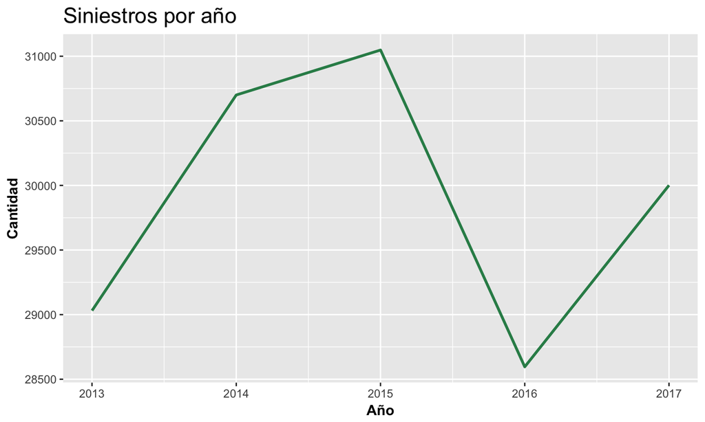

## Siniestros por día de la semana

[figure not shown]

## Siniestros por mes

Se puede observar un comportamiento bastante regular en los meses de los diferentes años. Hay dos picos claros en los meses de marzo y diciembre los cuales coinciden con semana de turismo y fin de año respectivamente, algo que es razonable ya que son momentos donde aumenta el movimiento vehicular.

## Siniestros por día de la semana

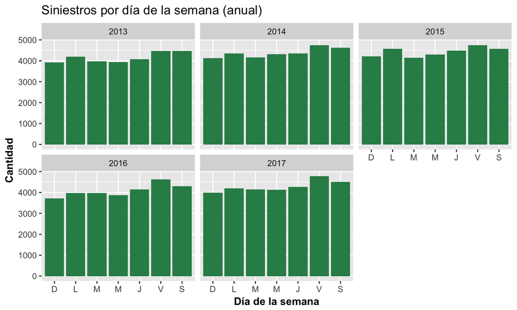

## Sieniestros por hora

A continuacion veremos las variaciones de cantidad de siniestros por hora. El comportamiento es muy similar en todos los años siendo el horario de 17 a 19 horas el que presenta mayor cantidad de siniestros.

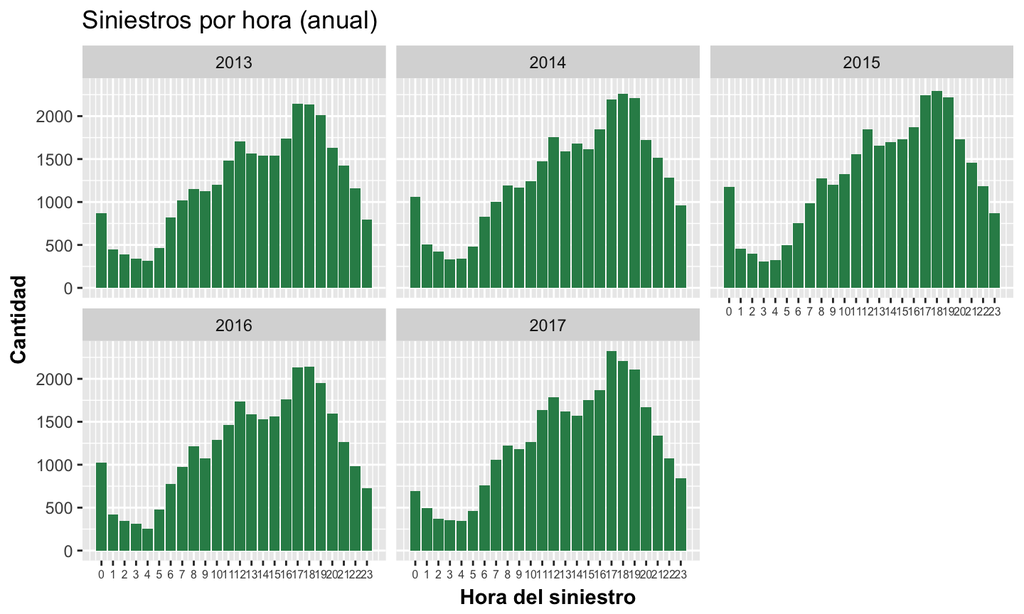

## Analisis de variables cualitativas

Luego de explorar temporalmente nuestro problema de interés pasamos a realizar el análisis a traves de las variables Tipo de siniestro y Gravedad, dos variables que a priori parecen ayudar en la caracterización del problema de estudio temporal.

## Accidentes según tipos de siniestro

Se observa que la colisión entre vehiculos es la principal causa de los siniestros siguiendo por las caídas y despiestes en menor medida. No se observa una diferencia significativa en las cantidades de siniestros de cada tipo en los diferentes años

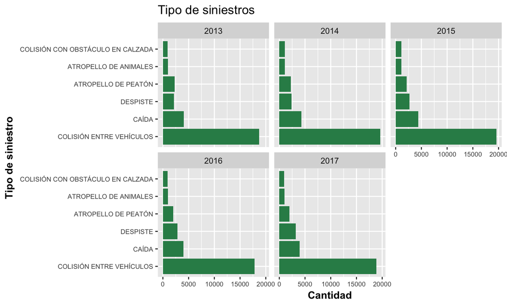

## Analisis de los siniestros según gravedad

Se puede observar que a lo largo de los años, las cantidades de siniestros fatales y graves se han mantenido casi constantes mientras que los siniestros con gravedad leve han disminuído y aumentado el número de accidentes sin lesionados aunque levemente. También destacamos que la mayoría de los siniestros tienen consecuencias leves o sin causar lesionados.

## Análisis de los siniestros según gravedad

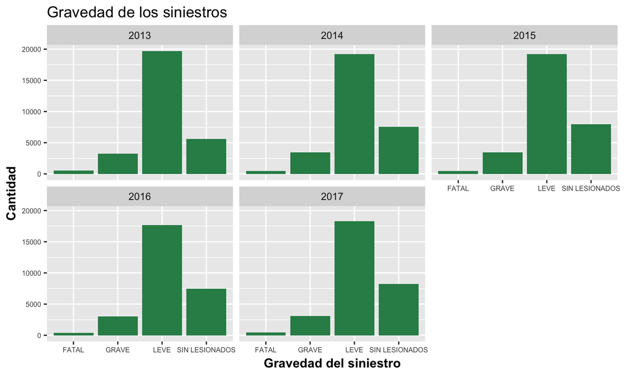

## Variables conjuntamente

Para darle más profundidad al análisis, realizamos una visualización de como estas dos variables se distribuyen conjuntamente en cada año para ver que relación existe entre el motivo del accidente y su consecuecia para los involucrados.

Como era esperable, los accidentes con menor proporción de no lesionados son los correspondientes a los atropellos de peatón siendo estos los tipos de siniestros con más resultados fatales. Algo quizás no tan esperado es que las colisiones con obstáculos tengan la mayor proporción de reslutados sin lesionados.

## Variables conjuntamente

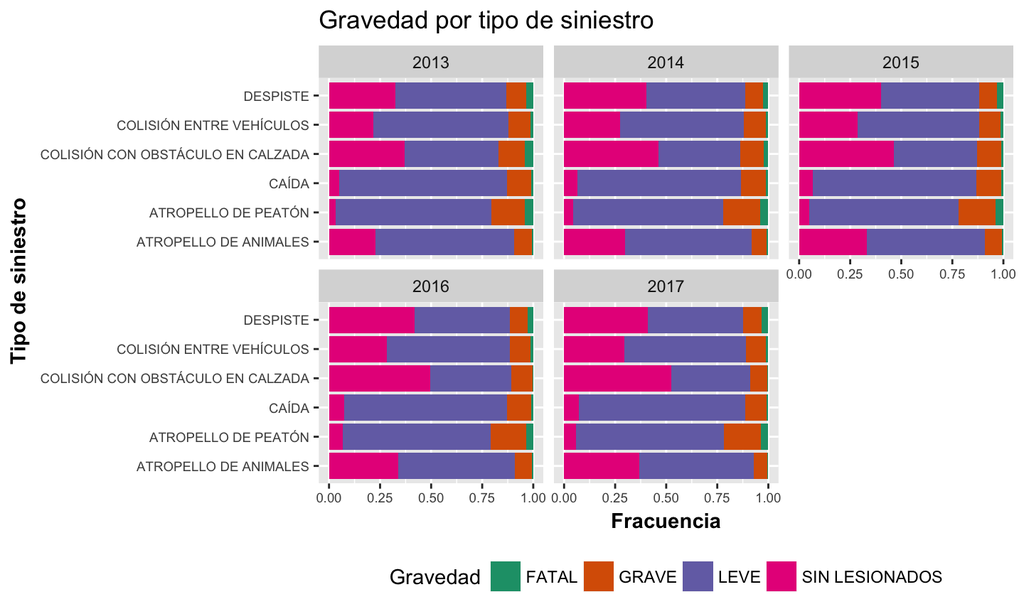

## Analisis espacial

Como poseemos la ubicacion en donde se ocurrió el accidente, es inetersante el contrastar como varía la cantidad de siniestros según el departamento en el que ocurrió. Se puede observar que Montevideo es claramente el departamento con mayor cantidad de siniestros, un correcto análisis de esta situación sería tomar en cuenta la población de cada departamento. Vemos que no hay grandes cambios en el correr de los años

## Analisis espacial

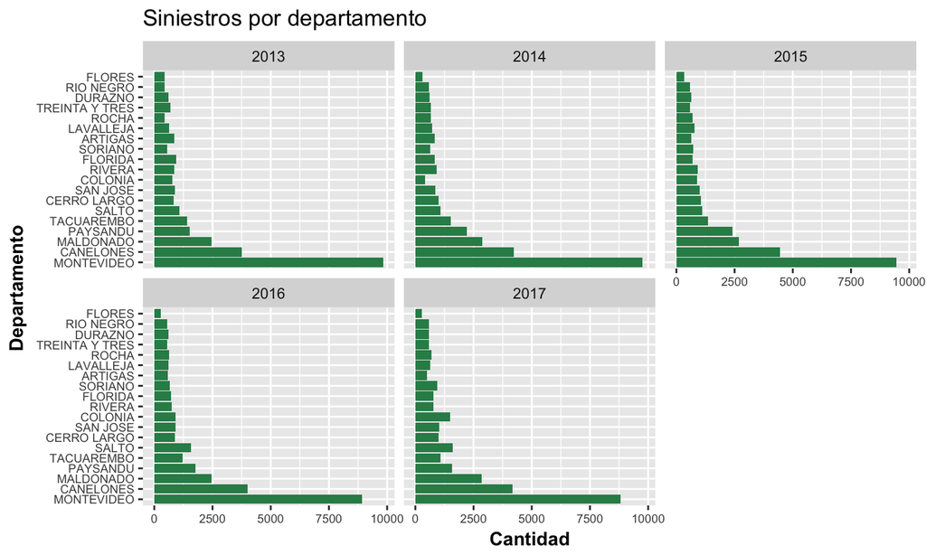

## Analisis espacial con variables cualitativas

Si bien el departamento nos da una cierta información de la cantidad de accidentes esperable, también puede estar correlacionada con la gravedad de los accidentes que ahi ocurren o con el tipo de los mismo. Para esto los analizaremos las variables de manera conjunta con la distribucion departamental.

## Tipo de siniestro según departamento

En todos los departamentos la mayoría de los siniestros son causados por la colisión entre vehículos. Montevideo es el que mayor número de atropello de peatones tiene.

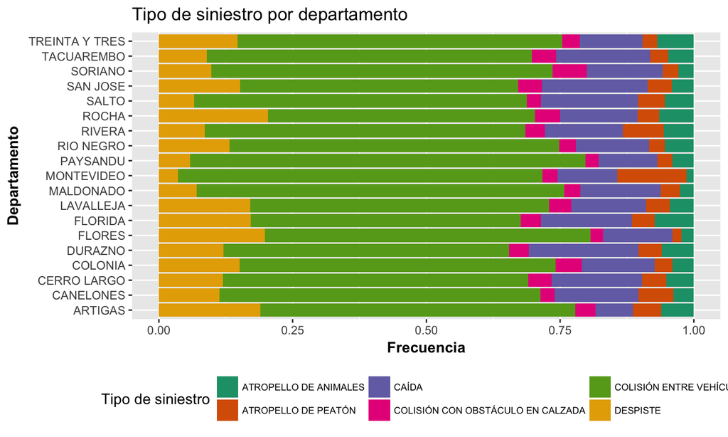

## Gravedad del siniestro según departamento

Para finalizar vamos a observar que relación existe entre la gravedad de los siniestros y el departamento. Claramente la mayoría de los siniestros para todos los departamentos son sin lesionados o lesionados leves. San José es quién tiene la mayor proporción de siniestros fatales y Paisandú el departamento con mayor proporción de siniestros sin lesionados.

## Gravedad del siniestro según departamento

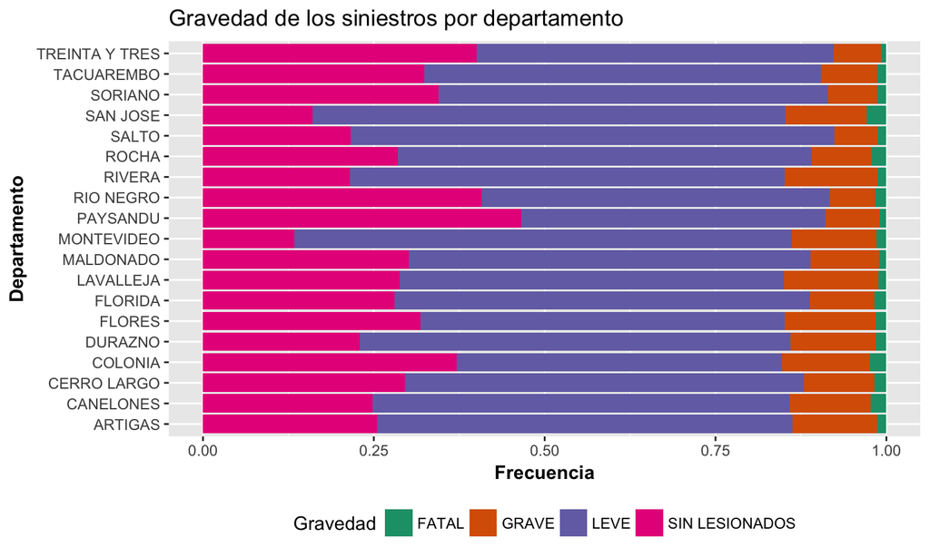

## Continuación del trabajo

Como principal continuación, se buscaría poder modelar y predecir los siniestros de años futuros utilizando modelación según series temporales. Así como esto, también el poder luego contrastar y evaluar los modelos propuestos con los resultados publicados a futuro. También se podría agregar una distribución geográfica más prescisa al análisis, llegando al punto de identificacion exacta de donde ocurrió el accidente basandose en coordenadas y las calles de ocurrencia.

## Bibliografía

- R for Data Science - Garrett Grolemund, Hadley Wickham (http://r4ds.had.co.nz/)
- ggplot2 Elegant Graphics for Data Analysis - Hadley Wickham
- Datos: Página web UNASEV (http://aplicaciones.unasev.gub.uy/mapas/AdministracionMapaIndicadores/AdministracionMapaIndicadores_Alta)